# ESP - Data Analysis

Haojia Li

Tianran Zhang

Zihan Yang

5/29/2020

```r
# read data
library(haven)
library(readxl)

# data manipulation
library(tidyverse)
# knit tables
library(knitr)
library(kableExtra)

# install.packages("RVAideMemoire")
library(RVAideMemoire) # fisher.multcomp with fdr
# install.packages("rstatix")
library(rstatix) # fisher_test with fdr

# Regression on weighted data
library(survey)
# PIAAC Regression
library(intsvy)
```

```r
# Load data from the Rdata folder in the Data folder
load("../Data/ESP.RData")
load("../Data/NYS.RData")
load("../Data/PIAAC.RData")
```

# Regression rsults (without weights consideration)

## Association between numeracy and self-reported health status

**Empire State Poll (ESP)**

**Empire State Poll (ESP)**

Step-wise multivariate linear regression

- Outcome: binary health status
1. Original Levels (Multi-level/Excellent/Very good/Good/Fair/Poor/Unknown)
2. Health status 1(Binary): Not Poor VS. Poor
3. Health status 2 (Binary): Good VS. Not Good
- Predictor: numeracy score
- Covariates: education, ethincity, income, race
- Interaction term: education & numeracy score

| Outcome | Health status 1 (Not Poor VS. Poor) | Health status 2 (Good VS. Not Good) |
| --- | --- | --- |
| significant predictor | numeracy score |  |
| significant covariates | Education, ethinicity | income, education |
| AUC | 0.8196 | 0.9327 |
| Power | 87.30% (85.08, 89.30) | 72.20% (69.31, 74.96) |

**Program for the International Assessment of Adult Competencies (PIAAC 2017)**

Step-wise multivariate linear regression

- Outcome: binary health status
- predictor: numeracy score
- covariates: income, race, education
- Interaction term: education & numeracy score

| Outcome | Health status 1 (Not Poor VS. Poor) | Health status 2 (Good VS. Not Good) |
| --- | --- | --- |
| significant predictor | numeracy score | numeracy score |
| significant covariates | income, race | income, race, education |
| AUC | 0.7469 | 0.7098 |
| Power | 99.80% (99.28, 99.98) | 100.0% (99.63, 100.0) |

Considering additional covariates:

- Outcome: binary health status
- predictor: numeracy score, literacy performance, problem solving
- covariates: income, race, education

| Outcome | Health status 1 (Not Poor VS. Poor) | Health status 2 (Good VS. Not Good) |
| --- | --- | --- |
| significant predictor | numeracy score | numeracy score |
| significant covariates | income, race, education, problem solving | income, race, education, problem solving |
| AUC | 0.8198 | 0.6907 |
| Power | 0.00% ( 0.00, 0.37) | 0.00% ( 0.00, 0.37) |

## Association between numeracy and visits to doctors

**Empire State Poll (ESP)**

**Step-wise multivariate linear regression**

- Outcome: binary visits to doctors
1. Original Levels (Never/1-2 times/Once every few months/Once a month/Twice a month/Once a week/2-3 times a week)

```r
quantile(ESP$RVq2)
```

```
##   0%  25%  50%  75% 100%
##    1    2    3    3    7
```

```r
table(ESP$RVq2)
```

```
##
##   1   2   3   4   5   6   7
##  72 237 296 102  59  23  11
```

2. Visit status (Binary): Not often (#visits <=2) VS. Often (#visits >= 3)
- Predictor: numeracy score
- Covariates: education, ethincity, income, race
- Interaction term: education & numeracy score

| Outcome | Visit to doctors (Not Often VS. Often) |
| --- | --- |
| significant predictor |  |
| significant covariates | education, ethnicity, race |
| AUC | 0.6348 |
| Power (for efucational status) | 87.80% (85.61, 89.76) |

## Refusal Rate

```r
# calculate the number of refuse or -1 (in JAqs) in each column
refuse <- sapply(ESP, function(x) sum(x%in%c("Refused",-1)))
# keep the columns that have refuse
refuse <- refuse[which(refuse>0)]
# append the refuse rate and create a data frame; -2 means remove `age` since it overlaps with age.cat
refuse.df <- rbind(refuse, refuse/8) %>% as.data.frame()
refuse.df <- refuse.df[,-2]
# set col- and rownames
colnames(refuse.df) <- c("Gender", "Age Level", "Education", "Race", "Ethnicity", "JAq1: Fractions", "JAq2: Percentages", "JAq3: Numerical Info")
rownames(refuse.df) <- c("Number", "%")
kable(refuse.df) %>% kable_styling()
```

|  | Gender | Age Level | Education | Race | Ethnicity | JAq1: Fractions | JAq2: Percentages | JAq3: Numerical Info |
| --- | --- | --- | --- | --- | --- | --- | --- | --- |
| Number | 2.00 | 6.00 | 2.00 | 11.00 | 3.000 | 2.00 | 3.000 | 3.000 |
| % | 0.25 | 0.75 | 0.25 | 1.38 | 0.375 | 0.25 | 0.375 | 0.375 |

## Comparing means of numeracy score by health status

Relationship between `numeracy score` and `health status`

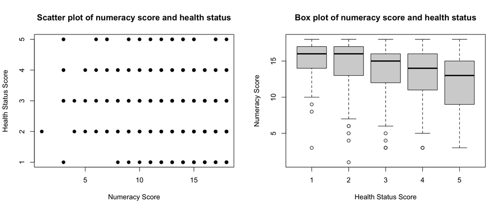

```r
par(mfrow = c(1,2))
plot(x=ESP$numeracy, y=ESP$JAq4, pch=19, xlab = "Numeracy Score", ylab = "Health Status Score", main = "Scatter plot of numeracy score and health status")
boxplot(numeracy~JAq4, data = ESP, xlab = "Health Status Score", ylab = "Numeracy Score", main = "Box plot of numeracy score and health status")
```

```r
# perform one-way ANOVA test
summary(aov(numeracy~health_status, data = ESP))
```

```
##                Df Sum Sq Mean Sq F value  Pr(>F)
## health_status   4    509   127.3    11.8 2.6e-09 ***
## Residuals     795   8577    10.8
## ---
## Signif. codes:  0 '***' 0.001 '**' 0.01 '*' 0.05 '.' 0.1 ' ' 1
```

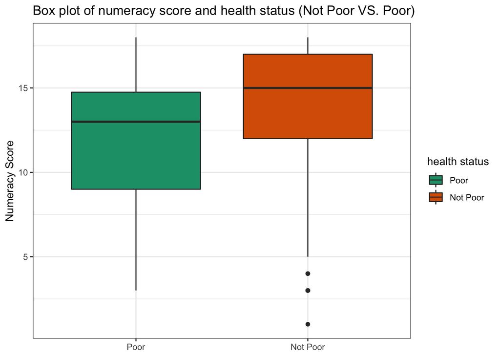

```r
ESP %>% ggplot() +
  geom_boxplot(aes(x=health_status_1, y=numeracy, fill=health_status_1)) +
  labs(title="Box plot of numeracy score and health status (Not Poor VS. Poor) ",y="Numeracy Score", x = NULL, fill="health status") +
  theme_bw() +
  # theme(plot.title = element_text(hjust = 0.5,size = 18)) +
  scale_fill_brewer(palette="Dark2")
```

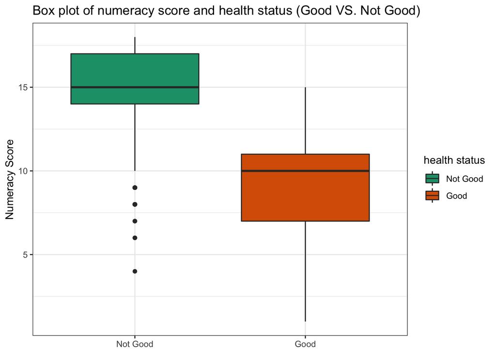

```r
ESP %>% ggplot() +
  geom_boxplot(aes(x=health_status_2, y=numeracy, fill=health_status_2)) +
  labs(title="Box plot of numeracy score and health status (Good VS. Not Good) ",y="Numeracy Score", x = NULL, fill="health status") +
  theme_bw() +
  # theme(plot.title = element_text(hjust = 0.5,size = 18)) +
  scale_fill_brewer(palette="Dark2")
```

## Comparing means of numeracy score by education

Relationship between `numeracy score` and `education`

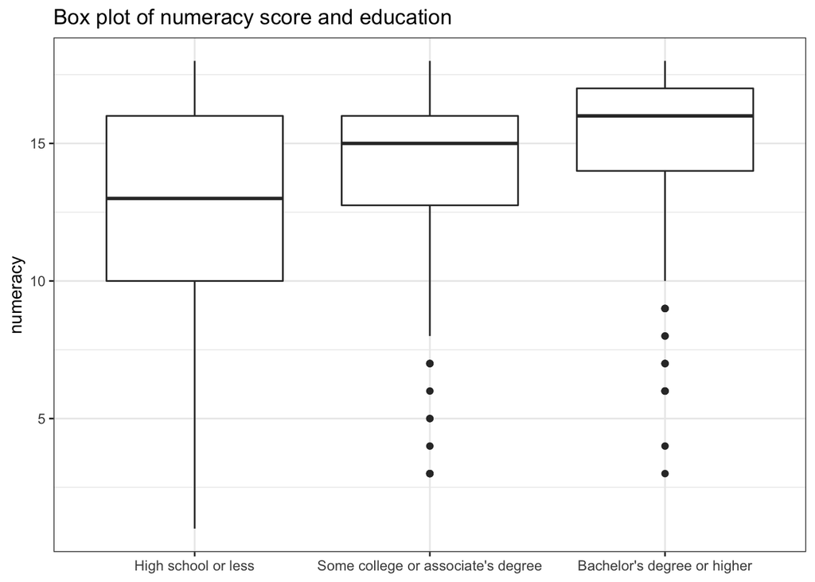

```r
ESP %>%
  filter(educ != "Refused") %>%
  group_by(educ) %>%
  ggplot() +
  geom_boxplot(aes(x=educ, y=numeracy)) +
  theme_bw() +
  labs(x = NULL, title = "Box plot of numeracy score and education")
```

```r
# performe one-way ANOVA test
summary(aov(numeracy~educ, data = ESP))
```

```
##              Df Sum Sq Mean Sq F value Pr(>F)
## educ          3    849   282.9    27.3 <2e-16 ***
## Residuals   796   8238    10.3
## ---
## Signif. codes:  0 '***' 0.001 '**' 0.01 '*' 0.05 '.' 0.1 ' ' 1
```

# ESP vs. NYS (Fisher’s test)

```r
cat.smry <- function(mat, labels = NULL) {
  perc <- paste0(round(prop.table(mat)*100,2),"%")
  n.perc <- paste0(mat,"(",perc,")")
  if(is.null(labels))
    names(n.perc) <- names(mat)
  else
    names(n.perc) <- labels
  return(n.perc)
}
# gather all the cat.smry result for ESP sample
ESP.smry <- c(cat.smry(table(ESP$gender)),
              cat.smry(table(ESP$age.cat)),
              cat.smry(table(ESP$educ)),
              cat.smry(table(ESP$income.cat)),
              cat.smry(table(ESP$race)),
              cat.smry(table(ESP$hisp)))

# join NYS.smry and ESP.smry together (drop levels such as "No data" and "Refused" which are unique for ESP sample by left join NYS)
comp1 <- data.frame(Demographics = rownames(NYS), NYS = NYS$n_perc) %>%
  left_join(data.frame(d = names(ESP.smry), ESP = ESP.smry), by = c("Demographics" = "d"))

# extract counts from ESP.smry
ESP.smry <- comp1$ESP
ESP.n <- c()
for(i in 1:length(ESP.smry)) {
  n.perc <- ESP.smry[i]
  n <- substr(n.perc, 1, unlist(gregexpr("\\(",n.perc))-1)
  ESP.n <- c(ESP.n, n)
}
ESP.n <- as.numeric(ESP.n)
# bind the counts of ESP and NYS preparing for fisher's test
fisher.mat <- rbind(ESP.n, unlist(NYS$counts)) %>% as.matrix()


# add subtitles of demographics
comp1 <- rbind(c("Gender", "", ""), comp1[1:2,],
              c("Age", "", ""), comp1[3:6,],
              c("Education", "", ""), comp1[7:9,],
              c("Income", "", ""), comp1[10:13,],
              c("Race", "", ""), comp1[14:18,],
              c("Ethnicity", "", ""), comp1[19:20,]) %>% as.data.frame()

# append p-values of fisher's test
comp1$pval <- sapply(list(1:2,3:6,7:9,10:13,14:18,19:20),
                     function(x){
                       mat <- fisher.mat[,x]
                       # pval <- fisher_test(mat)$p.value
                       # pval <- fisher.multcomp(mat)$p.signif
                       pval <- fisher.test(mat, simulate.p.value = T)$p.value
                       pval <- ifelse(pval<0.001, "<0.001", round(pval,3))
                       c(pval, rep("",length(x)))
                       }) %>% unlist()

kable(comp1, row.names = F) %>%
  kable_styling(full_width = F) %>%
  row_spec(c(1,4,9,13,18,24), bold = T)
```

| Demographics | NYS | ESP | pval |
| --- | --- | --- | --- |
| Gender |  |  | 0.214 |
| Male | 121301(48.41%) | 403(50.38%) |  |
| Female | 129262(51.59%) | 393(49.12%) |  |
| Age |  |  | 0.123 |
| 18-20 | 11851(4.73%) | 42(5.25%) |  |
| 21-44 | 103469(41.29%) | 298(37.25%) |  |
| 45-64 | 82455(32.91%) | 286(35.75%) |  |
| 65+ | 52788(21.07%) | 168(21%) |  |
| Education |  |  | <0.001 |
| High school or less | 97506(38.92%) | 184(23%) |  |
| Some college or associate’s degree | 69577(27.77%) | 224(28%) |  |
| Bachelor’s degree or higher | 83478(33.32%) | 390(48.75%) |  |
| Income |  |  | <0.001 |
| <$50k | 51303(33.03%) | 253(31.62%) |  |
| $50k-$100k | 64932(41.8%) | 262(32.75%) |  |
| $100k-$150k | 19158(12.33%) | 112(14%) |  |
| $150k+ | 19930(12.83%) | 143(17.88%) |  |
| Race |  |  | <0.001 |
| White | 13559(69.7%) | 543(67.88%) |  |
| Black | 3424(17.6%) | 103(12.88%) |  |
| Asian | 1770(9.1%) | 44(5.5%) |  |
| Natam | 195(1%) | 10(1.25%) |  |
| More than 1 race | 506(2.6%) | 38(4.75%) |  |
| Ethnicity |  |  | 0.667 |
| Hispanic | 41217(16.47%) | 126(15.75%) |  |
| Non-hispanic | 209046(83.53%) | 671(83.88%) |  |

We will try to use other methods like post-hoc analysis for multiple pairwise adjustment for anova in exact fisher’s test.

[fisher_test](https://rpkgs.datanovia.com/rstatix/reference/fisher_test.html)  
[fisher.multcomp](https://rdrr.io/cran/RVAideMemoire/man/fisher.multcomp.html)

## ESP (with weights)

So, here we only add survey weights to adjust the educationl level distribution in ESP data.

*Question:*

Do we also need to add survey weights on income and race even though they are not significant covariates?

(Comments:  
1. adjusted p-value mignt change a little bit from the unadjusted one.  
2. The levels of income would change from the current one (balance or power).  
3. For observation purporse, we might consider add income and race, the weight value would change.  
4. The weight would change if we will combine the design bias.  
Therefore, the one given above is the optimized solution we could provide with available information now.

*Question:*

What is the final supposed goal for here `PIACC vs. ESP` and `ESP vs. NYS`: Inference /Observation/Prediction?

*Question:*

So far we only consider the post-strafication weights without considering the design weights considering the sampling ratio.

(EG: Table 3 in [ESP methodology](https://sri.cornell.edu/sri/polls/files/esp/2019/ESP19%20-%20Introduction%20and%20Methodology%20Report.pdf))

## Info: Weights

**1. Weights are common used in sample survey for adjusting:**

1. Sample design (oversampling of some groups or disproportionate stratification)
2. Nonresponse
3. Bring sample backto being representative of the population ona select set of demographic characteristics

**2. Cnsensus on usage of weight:**

1. General consensus in the literature that weights should be use for descriptive statistics (e.g., Kish & Frankel, 1974)
2. Less consensus on whether weights should be routinely used in multivariate models, such as regression (e.g., Gelman, 2007 and comments; Kott, 2007; Winship & Radbill, 1994)

**Pros**

1. Allow us to claim our results are representative of the population (at least that they have the same distribution on major demographic characteristics as the population)
2. Used to adjust descriptive information on the sample

**Cons**

They introduce a substantial design effect into our data

1. Weights will increase the standard errors of our statistics making our findings less precise and more variable
2. The larger the variability in the weights the larger the design effects
3. This will affect most kinds of statistical analysis
- Descriptive statistics (means, percentages)
- Regression coefficients
- Other multivariate coefficients

**3. Method to test if the weight is needed:**

1. Sensitivity analysis—compare the coefficients of interest from analysis with and without weights. If not significantly different then weights unnecessary.
2. Add the weight and the interaction of the weight with each independent variable to the model. If these do not add significant amount of explained variance to the model, then weights not necessary.
3. When the weights have no effect on the parameter estimates they are called ignorable.

**4. Recommendation**

1. Compare basic substantive model with and without weights and including model-based variables. If same coefficients, unweighted data would be best because of smaller standard errors.
2. Test if a model with the weight and the interactions of the weight with all independent variables included adds significant explained variance. If yes, then use the weighted data or use a model-based approach.

**5. Types of weights**

1. Design Weights: related to sampling fraction(EG: Table 3 in [ESP methodology](https://sri.cornell.edu/sri/polls/files/esp/2019/ESP19%20-%20Introduction%20and%20Methodology%20Report.pdf))
2. Post-Stratification weights: realted to the demographical freatures of population Compute weights separately but sequentially.*(Question)*

**Using manual iterative solution**

```r
ESP.weighted <- ESP %>%
  filter(hisp != "Refused" & educ != "Refused") %>%
  mutate(hisp = factor(hisp), educ = factor(educ), wt = 1)


# This function generate survey weights automatically
surv.wt <- function(x, w, col_pos, col_name){
  # x: dataset of interest
  # w: NYS percentages
  # cpl_pos: column number of the variable to be weighted
  # col_name: name of the variable to be weighted

  x1 <- x %>%
    group_by_at(col_pos) %>%
    summarise(wt = sum(wt)/nrow(x)) %>%
    mutate(wt_new = w/wt) %>%
    select(-wt)

  merge(x, x1, by = col_name) %>%
    mutate(wt = wt * wt_new) %>%
    select(-wt_new)
}
```

```r
# Manully input the NYS education level proportion and hispanic proportion

wt.edu <- c(0.3892, 0.2777, 0.3332)
# wt.hisp <- c(0.1647, 0.8353)


ESP.weighted <- surv.wt(ESP.weighted, wt.edu, 7, "educ")
# ESP.weighted <- surv.wt(ESP.weighted, wt.hisp, c1 = 7, c2 = "hisp")
```

## Regression on weighted data

**Regression with health status 1 as the outcome**

```r
ESP.design <-svydesign(
        id = ~0,
        data = ESP.weighted ,
        weights = ~ wt
    )

sum1 <- summary(mysvyglm <- svyglm(health_status_1 ~ hisp + educ + numeracy, ESP.design,
                           family=quasibinomial()))
sum1 <- data.frame(sum1$coefficients[-1, c(1, 4)])
colnames(sum1) <- c("Estimate", "P-value")
sum1$sig <- ifelse(sum1$`P-value` <0.05, "*", "")


kable(sum1) %>%
  kable_styling(full_width = F)
```

Estimate

P-value

sig

hispNon-hispanic

-0.769

0.201

educSome college or associate’s degree

0.356

0.409

educBachelor’s degree or higher

2.143

0.002

numeracy

0.122

0.010

**Regression with health status 2 as the outcome**

```r
sum2 <- summary(mysvyglm <- svyglm(health_status_2 ~ hisp + educ + numeracy, ESP.design,
                           family=quasibinomial()))
sum2 <- data.frame(sum2$coefficients[-1, c(1, 4)])
colnames(sum2) <- c("Estimate", "P-value")
sum2$sig <- ifelse(sum2$`P-value` <0.05, "*", "")


kable(sum2) %>%
  kable_styling(full_width = F)
```

Estimate

P-value

sig

hispNon-hispanic

0.985

0.024

educSome college or associate’s degree

-0.255

0.515

educBachelor’s degree or higher

0.063

0.858

numeracy

-0.613

0.000

**Interesting finding:**  
In the first model with `health status 1` as the outcome, `educational level` and `numeracy` are significant. While in the second model with `health status 2` as the outcome, `ethnicity` and `numeracy` are significant.

# ESP vs. PIAAC (education, income and ethnicity)

Race is not comparable between the two samples since PIAAC combines race and ethnicity together as one variable.

- Solution: create a new variable named “hisp” indicated whether one person is hispanic or not.

The levels of the B_Q01A variable in PIAAC dataset matched the content of ISCED-97.

```r
# bind ESP and PIAAC together
demo <- rbind(data.frame(Study = "ESP", Education = ESP$educ,
                         Income = ESP$income.cat, Hisp = ESP$hisp),
              data.frame(Study = "PIAAC", Education = PIAAC$educ,
                         Income = PIAAC$income.cat, Hisp = PIAAC$hisp)) %>% as.data.frame()

demo <- demo %>%
  mutate(Education = factor(Education), Income = factor(Income),
         Hisp = factor(Hisp))

# gather cat.smry results for ESP and PIAAC
## -4 here means drop the "Refused" level in ESP$educ and the "Unknown" level in PIAAC$educ since each of them is the unique level for its study
## if we keep these two levels, we will find that there is no p-value output of compareGroup function
ESP.smry1 <- c(cat.smry(table(ESP$educ))[-4],cat.smry(table(ESP$income.cat)), cat.smry(table(ESP$hisp)))

PIAAC.smry <- c(cat.smry(table(PIAAC$educ))[-4],cat.smry(table(PIAAC$income.cat)), cat.smry(table(PIAAC$hisp)))

comp2 <- data.frame(Demographics=names(ESP.smry1), ESP=ESP.smry1, PIAAC=PIAAC.smry)
# add subtitles of demographics
comp2 <- rbind(c("Education", "", ""), comp2[1:3,],
               c("Income", "", ""), comp2[4:8,],
               c("Hisp", "", ""), comp2[9:11, ]) %>% as.data.frame()
rownames(comp2) <- NULL

# perform Fisher's test and append p-values to the data frame
p.educ <- fisher.test(table(demo$Study, demo$Education), simulate.p.value = T)$p.value
p.educ <- ifelse(p.educ<0.001, "0.001", round(p.educ,3))

p.income <- fisher.test(table(demo$Study, demo$Income), simulate.p.value = T)$p.value
p.income <- ifelse(p.income<0.001, "<0.001", round(p.income, 3))


p.hisp <- fisher.test(table(demo$Study, demo$Hisp), simulate.p.value = T)$p.value
p.hisp <- ifelse(p.hisp<0.001, "<0.001", round(p.hisp, 3))
comp2$pval <- c(p.educ, rep("",3), p.income, rep("",5), p.hisp, rep("", 3))

kable(comp2, row.names = F) %>%
  kable_styling(full_width = F) %>%
  row_spec(c(1,5, 11), bold = T)
```

| Demographics | ESP | PIAAC | pval |
| --- | --- | --- | --- |
| Education |  |  | 0.001 |
| High school or less | 184(23%) | 1699(48.89%) |  |
| Some college or associate’s degree | 224(28%) | 620(17.84%) |  |
| Bachelor’s degree or higher | 390(48.75%) | 1153(33.18%) |  |
| Income |  |  | <0.001 |
| <$50k | 253(31.62%) | 1346(38.73%) |  |
| $50k-$100k | 262(32.75%) | 1002(28.83%) |  |
| $100k-$150k | 112(14%) | 437(12.58%) |  |
| $150k+ | 143(17.88%) | 353(10.16%) |  |
| No Data | 30(3.75%) | 337(9.7%) |  |
| Hisp |  |  | <0.001 |
| Hispanic | 126(15.75%) | 439(12.63%) |  |
| Non-hispanic | 671(83.88%) | 3029(87.17%) |  |
| Refused | 3(0.38%) | 7(0.2%) |  |

## Info: Plausible value in PIAAC

PIAAC cannot provide individual-level results, because each adult answers only a small number of assessment questions. PIAAC provides reliable estimates of proficiency only at the national level, or at the level of large subgroups (e.g., females, employed, or college educated).

Plausible Values (PVs) allows PIAAC dataset information to be saved at the case level to estimate proficiency at the national or subgroup level. Each case’s PVs reflect not only that individual’s performance on the small number of items s/he answered, but also the performance of similar respondents on the rest of the PIAAC assessment.

Each individual case in the PIAAC dataset has a randomly chosen set of ten plausible values (PVs). All ten PVs must be used together to estimate proficiency, or else one understates the variability in the predicted outcomes. The randomly chosen set of PVs best represents the score distribution for a subgroup of adults.

reference:  
https://cran.r-project.org/web/packages/intsvy/intsvy.pdf  
https://nces.ed.gov/training/datauser/PIAAC_04/assets/PIAAC_04.pdf  
https://www.oecd.org/skills/piaac/piactools_16oct_for_web.pdf

*Question:*

Should we use either PV1 or the combination from PV1 to PV10?

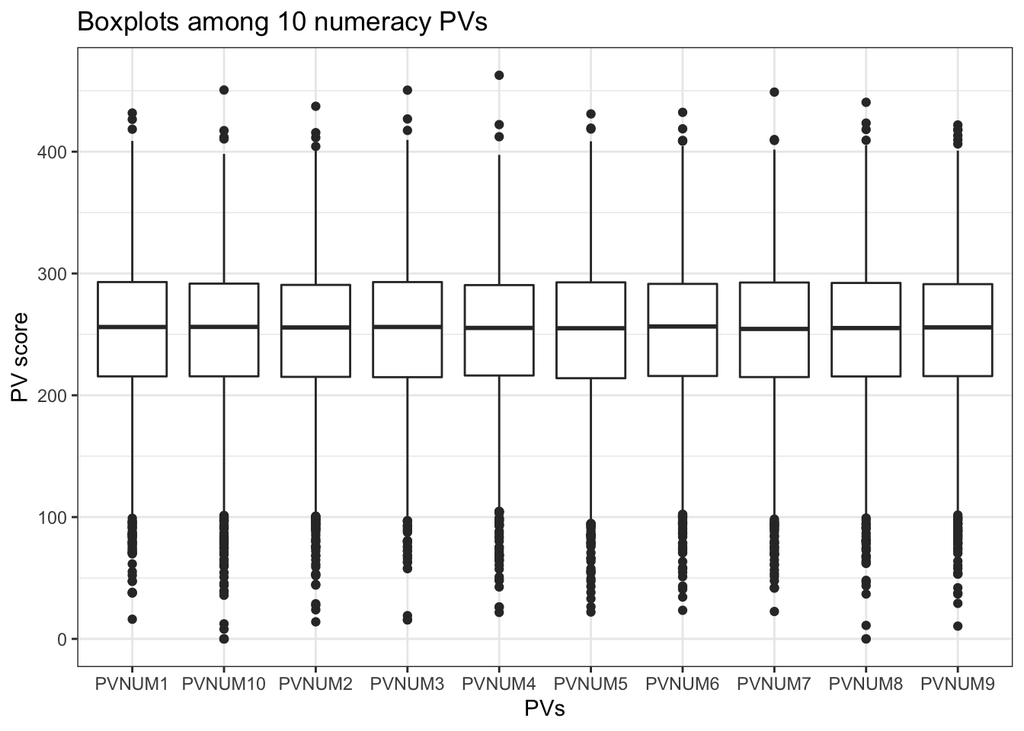

```r
# raw_PIAAC <- read_spss("../Data/prgusap1_puf.sav")
raw_PIAAC <- read_spss("../Data/prgusap1_puf.sav")
num_pv <- paste0("PVNUM", 1:10)
# paste(num_pv, collapse = " + ")

pv <- raw_PIAAC[, num_pv] %>%
  gather(key = "PVs", value = "value")
#table1(~ PVNUM1 + PVNUM2 + PVNUM3 + PVNUM4 + PVNUM5 + PVNUM6 +
#         PVNUM7 + PVNUM8 + PVNUM9 + PVNUM10, data = pv)

ggplot(data = pv) +
  geom_boxplot(aes(x = PVs, y = value)) +
  scale_x_discrete() +
  ggtitle("Boxplots among 10 numeracy PVs") +
  ylab("PV score") +
  theme_bw()
```

```r
summary(aov(value ~ PVs, data = pv))
```

```
##                Df    Sum Sq Mean Sq F value Pr(>F)
## PVs             9      3261     362    0.11      1
## Residuals   34780 116309634    3344
## 1810 observations deleted due to missingness
```

ANOVA test shows that there is no significant difference between these 10 PVs.

## Correlation: health status vs. numeracy score

The numeracy proficiency score are calculated with the implemented function “piaac.mean.pv” in the package “intsvy”. This function uses ten plausible values to calculate the mean achievement score and its standard error.

The t-test statistics are calculated using the online t-test calculator:  
https://select-statistics.co.uk/calculators/two-sample-t-test-calculator/

Health Staus 1 : Not Poor VS. Poor  
Health status 2: Good VS. Not Good

```r
PIAAC.pv <- cbind(PIAAC[, c("educ", "income.cat", "race",
                            "health_status_1", "health_status_2")],
                  raw_PIAAC %>% filter(!is.na(I_Q08)))

pv1 <- piaac.mean.pv(pvlabel = "NUM", by = "health_status_1", data = PIAAC.pv)[-3, 1:4]
pv1$p_val <- c("<0.001", "")
pv1 %>%
  kable()%>%
  kable_styling(full_width = F)
```

| health_status_1 | Freq | Mean | s.e. | p_val |
| --- | --- | --- | --- | --- |
| Not Poor | 3354 | 254 | 1.39 | <0.001 |
| Poor | 121 | 227 | 6.44 |  |

```r
pv2 <- piaac.mean.pv(pvlabel = "NUM", by = "health_status_2", data = PIAAC.pv) [-3, 1:4]
pv2$p_val <- c("<0.001", "")
pv2 %>%
  kable()%>%
  kable_styling(full_width = F)
```

| health_status_2 | Freq | Mean | s.e. | p_val |
| --- | --- | --- | --- | --- |
| Good | 2851 | 258 | 1.50 | <0.001 |
| Not Good | 624 | 230 | 2.49 |  |

The two-sample t-test results show that numeracy score is positively associated with people’s health status.

# Question Summary

1. Do we also need to add survey weights on income and race even though they are not significant covariates?

2.What is the final supposed goal for here `PIACC vs. ESP` and `ESP vs. NYS`: Inference /Observation/Prediction?

3. So far we only consider the post-strafication weights without considering the design weights considering the sampling ratio. (EG: Table 3 in [ESP methodology](https://sri.cornell.edu/sri/polls/files/esp/2019/ESP19%20-%20Introduction%20and%20Methodology%20Report.pdf))
4. Post-Stratification weights: realted to the demographical freatures of population Compute weights separately but sequentially.
5. Should we use either PV1 or the combination from PV1 to PV10?